# Classifying movement types by their properties

2024-03-12

# Summary

The accuracy estimates for the RF, BCT, and GBM classifiers were 0.993, 0.982, and 0.974, respectively, suggesting these techniques were able to often able to correctly identify the type of Classe. The stacked model performed slightly better (accuracy=0.994). These accuracy statistics suggest the individual classifiers will incorrectly identify the Classe of exercise in 7, 18, 26, and 6 cases for every 1,000 examined.

Although not provided here, the stacked classifier was used to predict the classe of exercise from a separate set of 20 individual cases.

# Data

The data were obtained from a website archived on the WayBackMachine (http://web.archive.org/web/20161224072740/http:/groupware.les.inf.puc-rio.br/har) and were used in a scientific publication:

Velloso, E.; Bulling, A.; Gellersen, H.; Ugulino, W.; Fuks, H. Qualitative Activity Recognition of Weight Lifting Exercises. Proceedings of 4th International Conference in Cooperation with SIGCHI (Augmented Human ’13) . Stuttgart, Germany: ACM SIGCHI, 2013.

The data includes gyroscopic, accelerometer, and magnetometer measurements from 5 sensors attached to each of 6 untrained individuals (aged 20-28) performing dumbell curls correctly (Classe A) or in one of four predetermined incorrect postures:

- throwing the elbows to the front (Class B),
- lifting the dumbbell only halfway (Class C),
- lowering the dumbbell only halfway (Class D), and
- throwing the hips to the front (Class E).

# Methods

### Pre-selecting variables from the 160 available in the training set

The original training set provided for this assessment included ~160 measurement variables. Many of these variables were incomplete and which variables to include required some attention.

The ultimate goal of this project (predicting the classe of activities in the original test data), the variables with no data for a given activity, such as ‘amplitude_pitch_arm’ were removed from the original training set. Removing these data from the original training set left 52 variables with no missing measurements. These 52 variables, including accel_arm_x were used as the predictor variables to classify Classe.

### Splitting the original training set into sub-test and sub-test sets

To determine the success of the classifiers, the original training set was further partitioned into a sub-training and sub-test sets (70/30 training/test split) using the createDataPartition function in the caret package.

### Selecting classifiers

Using the sub-training data, and a brief review of the caret package literature (https://topepo.github.io/caret/train-models-by-tag.html) and the course notes, 3 classification approaches were selected:

- random forest (RF),
- bagged classification tree (BCT), and
- gradient boosting machine (GBM).

### Cross-validation

Cross-validation was performed using the training set data. A 10-fold cross-validation procedure was performed inside the train() function from the caret package.

The models derived from these techniques were used to predict the known Classe from the sub-test set. Additionally, the predictions from these 3 classifiers were further stacked and used (also in a RF) to further predict the known Classes and determine if the stacked model performed better than the individual classifiers.

# Results of 3 individual and 1 stacked classification

These results shown in Figures 1-4, along with those found in Table 1, suggest the predictors performed very well with the lowest accuracy being 97.4%. However, the stacked predictor tended to perform the best. The accuracy of the stacked classifier was 0.994 with a 95% confidence interval of 0.991 to 0.996. The stacked classifier was used to predict the Classes for the original test set (and to answer the questions in the quiz.)

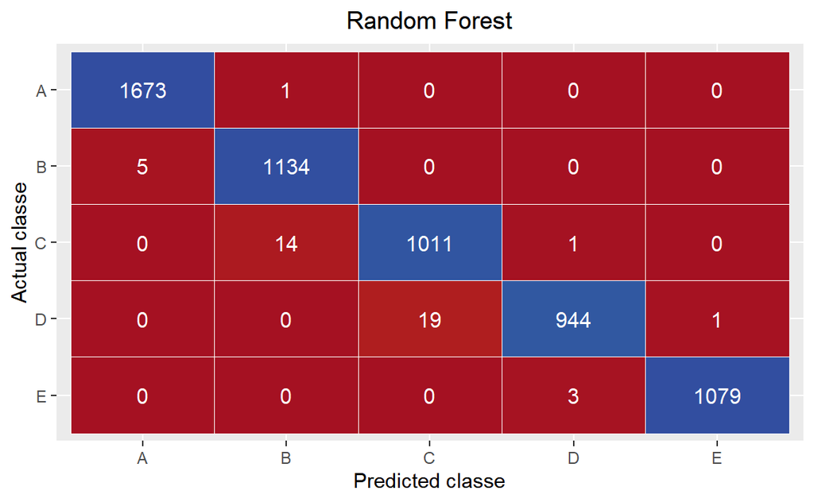

Figure 1: Confusion matrix results of Random Forest between predicted and actual classes; numbers shown in cells are numbers in each category (e.g., actually in Classe A, but predicted to occur in Class B; values along diagonal were correctly classified; cells colored by proportion of actual Classe (rows) falling in each predicted Classe (columns); coloring of cells shows low (red) to high (blue).

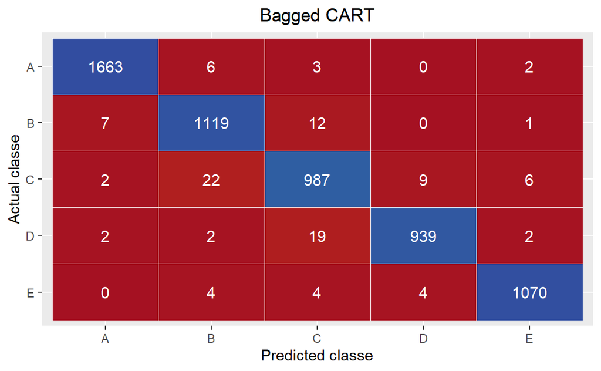

Figure 2: Confusion matrix results of bagged classification trees between predicted and actual classes; numbers shown in cells are numbers in each category (e.g., actually in Classe A, but predicted to occur in Class B; values along diagonal were correctly classified; cells colored by proportion of actual Classe (rows) falling in each predicted Classe (columns); coloring of cells shows low (red) to high (blue).

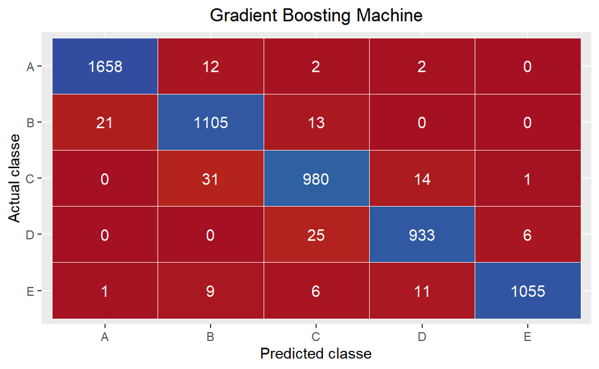

Figure 3: Confusion matrix results of gradient boosting machines between predicted and actual classes; numbers shown in cells are numbers in each category (e.g., actually in Classe A, but predicted to occur in Class B; values along diagonal were correctly classified; cells colored by proportion of actual Classe (rows) falling in each predicted Classe (columns); coloring of cells shows low (red) to high (blue).

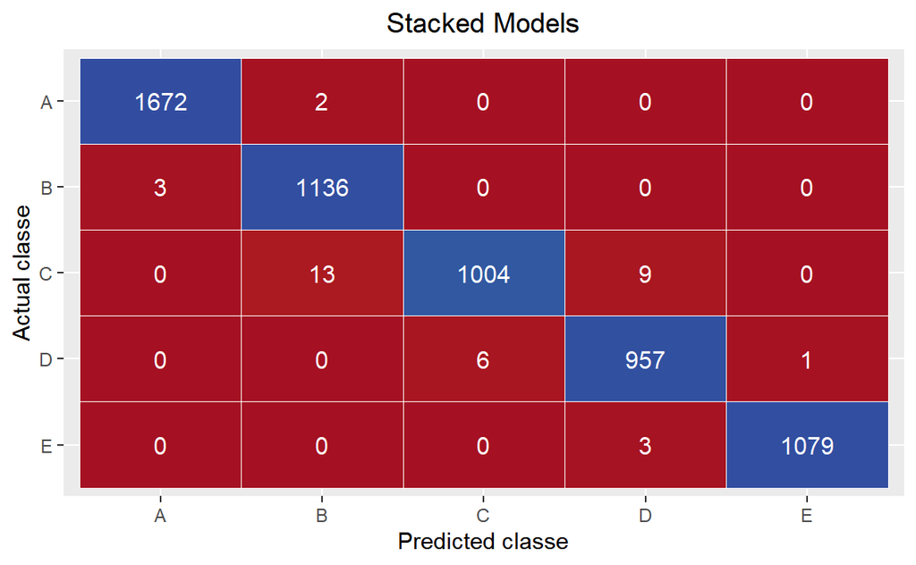

Figure 4: Confusion matrix results of the stacked classification model between predicted and actual classes; numbers shown in cells are numbers in each category (e.g., actually in Classe A, but predicted to occur in CLass B; values along diagonal were correctly classified; cells colored by proportion of actual Classe (rows) falling in each predicted Classe (columns); coloring of cells shows low (red) to high (blue).

Table 1: Summary statistics of the random forest, bagged classification tree, gradient boosting machine, and stacked classifiers.

| Algorithm | Accuracy | Accuracy (95% CI) | Null Accuracy | Accuracy p-value | Kappa |
| --- | --- | --- | --- | --- | --- |
| Random.Forest | 0.993 | 0.99 to 0.995 | 0.284 | <0.001 | 0.991 |
| Bagged.CART | 0.982 | 0.978 to 0.985 | 0.284 | <0.001 | 0.977 |
| Gradient.Boosting.Machine | 0.974 | 0.969 to 0.978 | 0.284 | <0.001 | 0.967 |
| Model.Stacking | 0.994 | 0.991 to 0.996 | 0.284 | <0.001 | 0.992 |